# Reproducible Research Course Project 2

# Health and Econimic Consequences of Storms ans Severe Weather Events in U.S.

## Synopsis

This project explores the U.S. National Oceanic and Atmospheric Administration’s (NOAA) storm database. This database tracks characteristics of major storms and weather events in the United States, including when and where they occur, as well as estimates of any fatalities, injuries, and property an crop damage. The analysis that is made estimates which types of weather events have the greatest impact on the public health and the economic damage on properties and crops respectively, across the United States.

## Data Processing

We obtained the data from the U.S. National Oceanic and Atmospheric Administration’s (NOAA) storm database. This database tracks characteristics of major storms and weather events in the United States, including when and where they occur, as well as estimates of any fatalities, injuries, and property damage. https://d396qusza40orc.cloudfront.net/repdata%2Fdata%2FStormData.csv.bz2 The events in the database start in the year 1950 and end in November 2011.

### Downloading and reading the data

First we download the data and read the data.csv file.

```r
url <- "https://d396qusza40orc.cloudfront.net/repdata%2Fdata%2FStormData.csv.bz2"
download.file(url, destfile = "data.bz2", method = "curl")
data <- read.csv(bzfile("data.bz2"))
```

After we read the data we check the first few rows. There are 902297 rows in this dataset.

```r
dim(data)
```

```
## [1] 902297     37
```

```r
head(data)
```

```
##   STATE__           BGN_DATE BGN_TIME TIME_ZONE COUNTY COUNTYNAME STATE
## 1       1  4/18/1950 0:00:00     0130       CST     97     MOBILE    AL
## 2       1  4/18/1950 0:00:00     0145       CST      3    BALDWIN    AL
## 3       1  2/20/1951 0:00:00     1600       CST     57    FAYETTE    AL
## 4       1   6/8/1951 0:00:00     0900       CST     89    MADISON    AL
## 5       1 11/15/1951 0:00:00     1500       CST     43    CULLMAN    AL
## 6       1 11/15/1951 0:00:00     2000       CST     77 LAUDERDALE    AL
##    EVTYPE BGN_RANGE BGN_AZI BGN_LOCATI END_DATE END_TIME COUNTY_END
## 1 TORNADO         0                                               0
## 2 TORNADO         0                                               0
## 3 TORNADO         0                                               0
## 4 TORNADO         0                                               0
## 5 TORNADO         0                                               0
## 6 TORNADO         0                                               0
##   COUNTYENDN END_RANGE END_AZI END_LOCATI LENGTH WIDTH F MAG FATALITIES
```

[output cut: 20 more lines]

Load libraries.

```r
library(knitr)
library(markdown)
library(rmarkdown)
library(plyr)
```

```r
library(stats)
library(ggplot2)
library(reshape2)
```

### Subset and process the data

We subsetted the data with the variables needed for this analysis. We make a new data frame with the following variables: - EVTYPE: Type of event  
- FATALITIES: Number of fatalities  
- INJURIES: Number of injuries  
- PROPDMG: Propery Damage  
- PROPDMGEXP: Units for Property Damage (K,B,M) - CROPDMG: Crop Damage - CROPDMGEXP: Units for Crop Damage (K,B,M)

```r
names(data)
```

```
##  [1] "STATE__"    "BGN_DATE"   "BGN_TIME"   "TIME_ZONE"  "COUNTY"
##  [6] "COUNTYNAME" "STATE"      "EVTYPE"     "BGN_RANGE"  "BGN_AZI"
## [11] "BGN_LOCATI" "END_DATE"   "END_TIME"   "COUNTY_END" "COUNTYENDN"
## [16] "END_RANGE"  "END_AZI"    "END_LOCATI" "LENGTH"     "WIDTH"
## [21] "F"          "MAG"        "FATALITIES" "INJURIES"   "PROPDMG"
## [26] "PROPDMGEXP" "CROPDMG"    "CROPDMGEXP" "WFO"        "STATEOFFIC"
## [31] "ZONENAMES"  "LATITUDE"   "LONGITUDE"  "LATITUDE_E" "LONGITUDE_"
## [36] "REMARKS"    "REFNUM"
```

```r
dataUse<- data[,c("EVTYPE", "FATALITIES","INJURIES","PROPDMG","PROPDMGEXP","CROPDMG","CROPDMGEXP")]
```

Calculate the damage property and crop values. First we replace PROPDMGEXP and CROPDMGEXP values with the appropriate multipliers and calulate the damage.

```r
dataUse$PROPDMGEXP <- as.character(dataUse$PROPDMGEXP)
dataUse$CROPDMGEXP <- as.character(dataUse$CROPDMGEXP)
dataUse$PROPDMGEXP <- mapvalues(dataUse$PROPDMGEXP, from = c("" , "-", "?" ,"+", "0", "1", "2", "3", "4", "5", "6", "7", "8", "B", "h", "H", "K","m", "M"), to=c("0","0","0","1","10","10","10","10","10","10","10","10","10", "1000000000","100","100","1000","1000000","1000000"))
dataUse$PROPDMGEXP<- as.numeric(dataUse$PROPDMGEXP)
dataUse$PROPDMGVAL <- dataUse$PROPDMG*dataUse$PROPDMGEXP

dataUse$CROPDMGEXP <- mapvalues(dataUse$CROPDMGEXP, from = c("" , "M" ,"K", "m", "B", "?", "0", "k", "2"), to = c("0","1000000","1000","1000000","1000000000","0","10","1000","10"))
dataUse$CROPDMGEXP<- as.numeric(dataUse$CROPDMGEXP)
dataUse$CROPDMGVAL <- dataUse$CROPDMG*dataUse$CROPDMGEXP
```

## Results

### Which types of events is most harmful for bublic health in the U.S.

Calculate the total number of fatalities per event, and the total number of injuries per event.

```r
fatalitiesSum <- aggregate(FATALITIES ~ EVTYPE, data = dataUse, sum)
injuriesSum <- aggregate(INJURIES ~ EVTYPE, data = dataUse, sum)
fatalitiesSum <- fatalitiesSum[order(fatalitiesSum$FATALITIES, decreasing = TRUE),]
injuriesSum <- injuriesSum[order(injuriesSum$INJURIES, decreasing = TRUE),]
```

Plot the number of fatalities and injuries for the events for the 10 highest number of fatalities and injuries respectively.

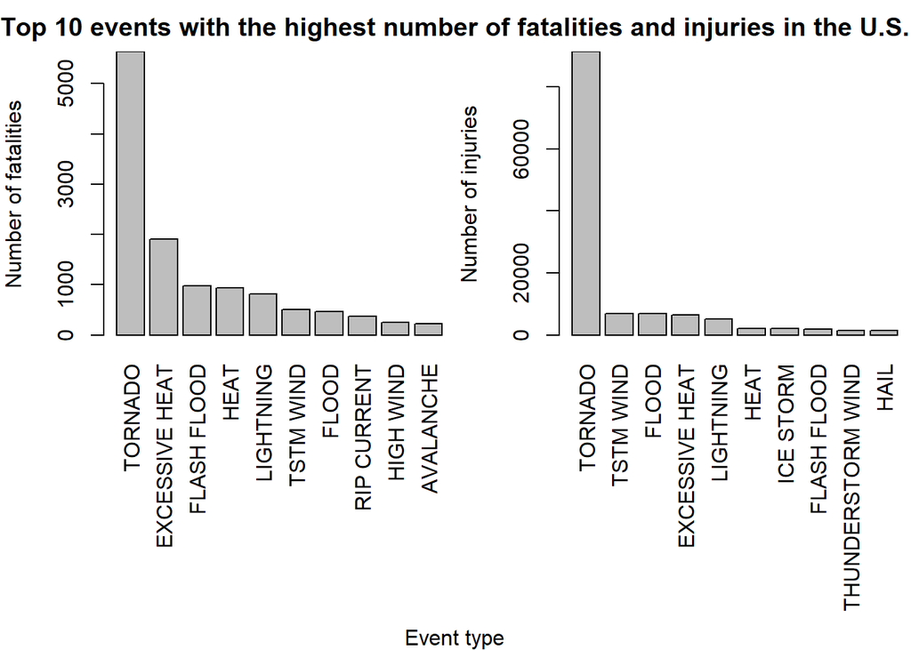

```r
par(mfrow = c(1,2), mar= c(10,4,0,0), oma = c(2,0,2,0))
barplot(fatalitiesSum$FATALITIES[1:10], names.arg = fatalitiesSum$EVTYPE[1:10],las = 3, ylab = "Number of fatalities")
barplot(injuriesSum$INJURIES[1:10], names.arg = injuriesSum$EVTYPE[1:10],las = 3, ylab = "Number of injuries")
title("Top 10 events with the highest number of fatalities and injuries in the U.S.", outer = TRUE)
mtext('Event type', side = 1, outer = TRUE, line =1)
```

### Which types of events have the greatest economic consequences in the U.S

Calculate the total value of damage in property and crop per event type, as well as the total value of damage for both and select the 10 event types with the highest total economic damage.

```r
dataUse$DMGTOTAL <- dataUse$PROPDMGVAL + dataUse$CROPDMGVAL
economicdata <- aggregate(cbind(PROPDMGVAL,CROPDMGVAL,DMGTOTAL)~ EVTYPE, data = dataUse, sum)
economicdata <- economicdata[order(economicdata$DMGTOTAL,decreasing = TRUE),]
ecdatatop10 <- economicdata[1:10,]
```

Plot the 10 event types with the highest total economic damage, along with the damage in property and crop for every event.

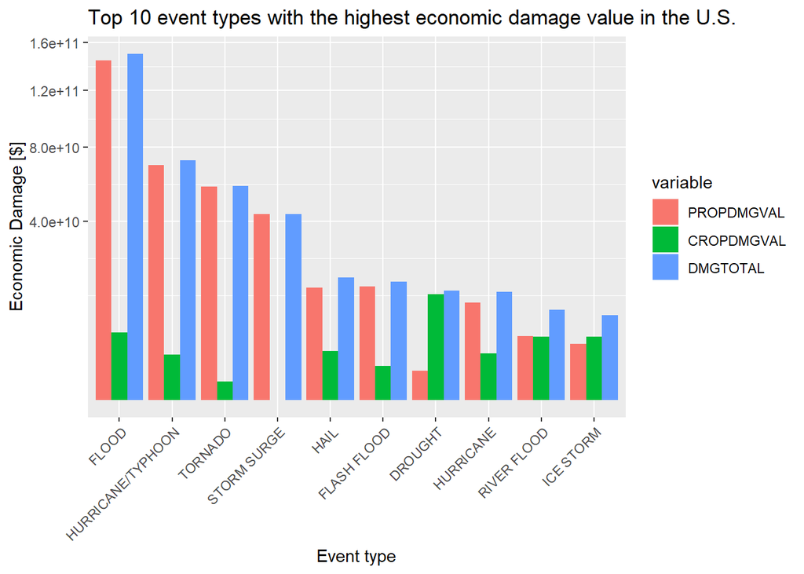

```r
economicDataTopMelt <- melt(ecdatatop10, id.vars="EVTYPE")
gg <- ggplot(economicDataTopMelt, aes(x=reorder(EVTYPE,-value), y = value))
gg <- gg + geom_bar(stat = "identity", aes(fill = variable), position = "dodge")
gg <- gg + scale_y_sqrt("Economic Damage [$]")
gg <- gg + xlab("Event type")
gg <- gg + theme(axis.text.x = element_text(angle=45, hjust=1))
gg <- gg + ggtitle("Top 10 event types with the highest economic damage value in the U.S. ")
plot(gg)
```

### Coclusions

- According to the above analysis, the most harmful for the public health event type is Tornado, which is responsible for the maximun number of fatalitites as well as injuries, in the U.S.
- According to the above analysis, the event type which caused the maximum total economic damage (property damage + crop damage) is flood.